# bankDNN

**Objective**: is to build a neural network-based classifier to determine whether the customer will leave or not in the next 6 months.

**Context:** Businesses like banks that provide service have to worry about the problem of 'Churn' i.e. customers leaving and joining another service provider. It is important to understand which aspects of the service influence a customer's decision in this regard. Management can concentrate efforts on the improvement of service, keeping in mind these priorities.

The dataset contains 10,000 sample points with 14 distinct features such as CustomerId, CreditScore, Geography, Gender, Age, Tenure, Balance, etc.

**Install shap, tensorflow, keras, hipplot and other necessary package**

```python
! pip install shap
```

```
     |████████████████████████████████| 358kB 5.6MB/s
```

```python
!pip install hiplot
```

[output not shown]

```python
!pip install tensorflow==2.3
```

[output not shown]

```python
import tensorflow as tf
```

```python
print(tf.__version__)
```

```
2.3.0
```

```python
!pip install keras
!pip install -U keras-tuner
```

```
     |████████████████████████████████| 71kB 3.8MB/s
```

**1.Import All necessary Libraries**

```python
# Import All Libraries
import pandas as pd
import numpy as np
from sklearn import metrics
import matplotlib.pylab as plt
%matplotlib inline
import seaborn as sns
from sklearn.model_selection  import train_test_split
from scipy.stats import zscore
import tensorflow as tf
from sklearn import preprocessing
from tensorflow.keras.models import Sequential
from tensorflow.keras.layers import Dense, Dropout, BatchNormalization
from sklearn.metrics import accuracy_score, confusion_matrix, precision_score, recall_score, f1_score, precision_recall_curve, auc
import matplotlib.pyplot as plt
from tensorflow.keras import optimizers
from kerastuner.tuners import RandomSearch
import hiplot as hip
from keras.utils.vis_utils import plot_model
from tensorflow.keras import layers
from tensorflow.keras import activations
```

**2. Read CSV file into dataframe variable**

```python
#Read CSV file into dataframe variable
bank_df = pd.read_csv("/content/sample_data/bank.csv")
bank_df  = bank_df.drop(columns=['RowNumber','CustomerId','Surname'],axis=1)
bank_df

# dropped or removed the following attributes RowNumber','CustomerId','Surnamey because there seems to be little to no correlation between whether a particular
# RowNumber','CustomerId gives more impact on the upselling of current customers or attracting new customers.
```

|  | CreditScore | Geography | Gender | Age | Tenure | Balance | NumOfProducts | HasCrCard | IsActiveMember | EstimatedSalary | Exited |
| --- | --- | --- | --- | --- | --- | --- | --- | --- | --- | --- | --- |
| 0 | 619 | France | Female | 42 | 2 | 0.00 | 1 | 1 | 1 | 101348.88 | 1 |
| 1 | 608 | Spain | Female | 41 | 1 | 83807.86 | 1 | 0 | 1 | 112542.58 | 0 |
| 2 | 502 | France | Female | 42 | 8 | 159660.80 | 3 | 1 | 0 | 113931.57 | 1 |
| 3 | 699 | France | Female | 39 | 1 | 0.00 | 2 | 0 | 0 | 93826.63 | 0 |
| 4 | 850 | Spain | Female | 43 | 2 | 125510.82 | 1 | 1 | 1 | 79084.10 | 0 |
| ... | ... | ... | ... | ... | ... | ... | ... | ... | ... | ... | ... |
| 9995 | 771 | France | Male | 39 | 5 | 0.00 | 2 | 1 | 0 | 96270.64 | 0 |
| 9996 | 516 | France | Male | 35 | 10 | 57369.61 | 1 | 1 | 1 | 101699.77 | 0 |
| 9997 | 709 | France | Female | 36 | 7 | 0.00 | 1 | 0 | 1 | 42085.58 | 1 |
| 9998 | 772 | Germany | Male | 42 | 3 | 75075.31 | 2 | 1 | 0 | 92888.52 | 1 |
| 9999 | 792 | France | Female | 28 | 4 | 130142.79 | 1 | 1 | 0 | 38190.78 | 0 |

10000 rows × 11 columns

```python
# The for loop written here converts all the object Dtypes into categorical types
for feature in bank_df.columns:
  if bank_df[feature].dtype == 'object' :
    bank_df[feature] == pd.Categorical(bank_df[feature])
bank_df.head()
```

|  | CreditScore | Geography | Gender | Age | Tenure | Balance | NumOfProducts | HasCrCard | IsActiveMember | EstimatedSalary | Exited |
| --- | --- | --- | --- | --- | --- | --- | --- | --- | --- | --- | --- |
| 0 | 619 | France | Female | 42 | 2 | 0.00 | 1 | 1 | 1 | 101348.88 | 1 |
| 1 | 608 | Spain | Female | 41 | 1 | 83807.86 | 1 | 0 | 1 | 112542.58 | 0 |
| 2 | 502 | France | Female | 42 | 8 | 159660.80 | 3 | 1 | 0 | 113931.57 | 1 |
| 3 | 699 | France | Female | 39 | 1 | 0.00 | 2 | 0 | 0 | 93826.63 | 0 |
| 4 | 850 | Spain | Female | 43 | 2 | 125510.82 | 1 | 1 | 1 | 79084.10 | 0 |

```python
# Here we define, convert and replace the string categorical values to numerical categorical value for ordering/ one hot encoding
replacestruct = {
                  "Geography": {"France":1,"Spain":2,"Germany":3},
                  "Gender": {"Female":0,"Male":1}
                }
bank_df = bank_df.replace(replacestruct)
```

**3. Find any missing values in dataframe**

```python
bank_df.isna().sum()
# It seems there is no missing values
```

```
CreditScore        0
Geography          0
Gender             0
Age                0
Tenure             0
Balance            0
NumOfProducts      0
HasCrCard          0
IsActiveMember     0
EstimatedSalary    0
Exited             0
dtype: int64
```

```python
bank_df.shape
bank_df.head(5)
# Getting the top five records from the source dataframe
```

|  | CreditScore | Geography | Gender | Age | Tenure | Balance | NumOfProducts | HasCrCard | IsActiveMember | EstimatedSalary | Exited |
| --- | --- | --- | --- | --- | --- | --- | --- | --- | --- | --- | --- |
| 0 | 619 | 1 | 0 | 42 | 2 | 0.00 | 1 | 1 | 1 | 101348.88 | 1 |
| 1 | 608 | 2 | 0 | 41 | 1 | 83807.86 | 1 | 0 | 1 | 112542.58 | 0 |
| 2 | 502 | 1 | 0 | 42 | 8 | 159660.80 | 3 | 1 | 0 | 113931.57 | 1 |
| 3 | 699 | 1 | 0 | 39 | 1 | 0.00 | 2 | 0 | 0 | 93826.63 | 0 |
| 4 | 850 | 2 | 0 | 43 | 2 | 125510.82 | 1 | 1 | 1 | 79084.10 | 0 |

**4. Find Correaltion between each variable**

```python
# Getting to know the correlation amongst the attributes
cor = bank_df.corr()
cor
```

|  | CreditScore | Geography | Gender | Age | Tenure | Balance | NumOfProducts | HasCrCard | IsActiveMember | EstimatedSalary | Exited |
| --- | --- | --- | --- | --- | --- | --- | --- | --- | --- | --- | --- |
| CreditScore | 1.000000 | 0.008267 | -0.002857 | -0.003965 | 0.000842 | 0.006268 | 0.012238 | -0.005458 | 0.025651 | -0.001384 | -0.027094 |
| Geography | 0.008267 | 1.000000 | -0.016936 | 0.048092 | 0.001418 | 0.348700 | -0.006180 | 0.004036 | -0.012692 | 0.007382 | 0.153771 |
| Gender | -0.002857 | -0.016936 | 1.000000 | -0.027544 | 0.014733 | 0.012087 | -0.021859 | 0.005766 | 0.022544 | -0.008112 | -0.106512 |
| Age | -0.003965 | 0.048092 | -0.027544 | 1.000000 | -0.009997 | 0.028308 | -0.030680 | -0.011721 | 0.085472 | -0.007201 | 0.285323 |
| Tenure | 0.000842 | 0.001418 | 0.014733 | -0.009997 | 1.000000 | -0.012254 | 0.013444 | 0.022583 | -0.028362 | 0.007784 | -0.014001 |
| Balance | 0.006268 | 0.348700 | 0.012087 | 0.028308 | -0.012254 | 1.000000 | -0.304180 | -0.014858 | -0.010084 | 0.012797 | 0.118533 |
| NumOfProducts | 0.012238 | -0.006180 | -0.021859 | -0.030680 | 0.013444 | -0.304180 | 1.000000 | 0.003183 | 0.009612 | 0.014204 | -0.047820 |
| HasCrCard | -0.005458 | 0.004036 | 0.005766 | -0.011721 | 0.022583 | -0.014858 | 0.003183 | 1.000000 | -0.011866 | -0.009933 | -0.007138 |
| IsActiveMember | 0.025651 | -0.012692 | 0.022544 | 0.085472 | -0.028362 | -0.010084 | 0.009612 | -0.011866 | 1.000000 | -0.011421 | -0.156128 |
| EstimatedSalary | -0.001384 | 0.007382 | -0.008112 | -0.007201 | 0.007784 | 0.012797 | 0.014204 | -0.009933 | -0.011421 | 1.000000 | 0.012097 |
| Exited | -0.027094 | 0.153771 | -0.106512 | 0.285323 | -0.014001 | 0.118533 | -0.047820 | -0.007138 | -0.156128 | 0.012097 | 1.000000 |

**5. Describe Characteristics of each variable**

```python
# Finding the distribution of data right from count, mean, std, min and max values for all the attributes using describe.
bank_df.describe()
```

|  | CreditScore | Geography | Gender | Age | Tenure | Balance | NumOfProducts | HasCrCard | IsActiveMember | EstimatedSalary | Exited |
| --- | --- | --- | --- | --- | --- | --- | --- | --- | --- | --- | --- |
| count | 10000.000000 | 10000.000000 | 10000.000000 | 10000.000000 | 10000.000000 | 10000.000000 | 10000.000000 | 10000.00000 | 10000.000000 | 10000.000000 | 10000.000000 |
| mean | 650.528800 | 1.749500 | 0.545700 | 38.921800 | 5.012800 | 76485.889288 | 1.530200 | 0.70550 | 0.515100 | 100090.239881 | 0.203700 |
| std | 96.653299 | 0.830433 | 0.497932 | 10.487806 | 2.892174 | 62397.405202 | 0.581654 | 0.45584 | 0.499797 | 57510.492818 | 0.402769 |
| min | 350.000000 | 1.000000 | 0.000000 | 18.000000 | 0.000000 | 0.000000 | 1.000000 | 0.00000 | 0.000000 | 11.580000 | 0.000000 |
| 25% | 584.000000 | 1.000000 | 0.000000 | 32.000000 | 3.000000 | 0.000000 | 1.000000 | 0.00000 | 0.000000 | 51002.110000 | 0.000000 |
| 50% | 652.000000 | 1.000000 | 1.000000 | 37.000000 | 5.000000 | 97198.540000 | 1.000000 | 1.00000 | 1.000000 | 100193.915000 | 0.000000 |
| 75% | 718.000000 | 3.000000 | 1.000000 | 44.000000 | 7.000000 | 127644.240000 | 2.000000 | 1.00000 | 1.000000 | 149388.247500 | 0.000000 |
| max | 850.000000 | 3.000000 | 1.000000 | 92.000000 | 10.000000 | 250898.090000 | 4.000000 | 1.00000 | 1.000000 | 199992.480000 | 1.000000 |

**6.Info about each variable in DF**

```python
bank_df.info()
```

```
<class 'pandas.core.frame.DataFrame'>
RangeIndex: 10000 entries, 0 to 9999
Data columns (total 11 columns):
 #   Column           Non-Null Count  Dtype
---  ------           --------------  -----
 0   CreditScore      10000 non-null  int64
 1   Geography        10000 non-null  int64
 2   Gender           10000 non-null  int64
 3   Age              10000 non-null  int64
 4   Tenure           10000 non-null  int64
 5   Balance          10000 non-null  float64
 6   NumOfProducts    10000 non-null  int64
 7   HasCrCard        10000 non-null  int64
 8   IsActiveMember   10000 non-null  int64
 9   EstimatedSalary  10000 non-null  float64
 10  Exited           10000 non-null  int64
dtypes: float64(2), int64(9)
memory usage: 859.5 KB
```

**7. Find count of any missing values and duplicates**

```python
bank_df.isnull().count()
bank_df.duplicated()
```

```
0       False
1       False
2       False
3       False
4       False
        ...
9995    False
9996    False
9997    False
9998    False
9999    False
Length: 10000, dtype: bool
```

**8. Print out names of all the columns in dataframe**

```python
bank_df.columns
```

```
Index(['CreditScore', 'Geography', 'Gender', 'Age', 'Tenure', 'Balance',
       'NumOfProducts', 'HasCrCard', 'IsActiveMember', 'EstimatedSalary',
       'Exited'],
      dtype='object')
```

**9. Print all stats/metrics of each columns**

```python
bank_df.describe().transpose()
```

|  | count | mean | std | min | 25% | 50% | 75% | max |
| --- | --- | --- | --- | --- | --- | --- | --- | --- |
| CreditScore | 10000.0 | 650.528800 | 96.653299 | 350.00 | 584.00 | 652.000 | 718.0000 | 850.00 |
| Geography | 10000.0 | 1.749500 | 0.830433 | 1.00 | 1.00 | 1.000 | 3.0000 | 3.00 |
| Gender | 10000.0 | 0.545700 | 0.497932 | 0.00 | 0.00 | 1.000 | 1.0000 | 1.00 |
| Age | 10000.0 | 38.921800 | 10.487806 | 18.00 | 32.00 | 37.000 | 44.0000 | 92.00 |
| Tenure | 10000.0 | 5.012800 | 2.892174 | 0.00 | 3.00 | 5.000 | 7.0000 | 10.00 |
| Balance | 10000.0 | 76485.889288 | 62397.405202 | 0.00 | 0.00 | 97198.540 | 127644.2400 | 250898.09 |
| NumOfProducts | 10000.0 | 1.530200 | 0.581654 | 1.00 | 1.00 | 1.000 | 2.0000 | 4.00 |
| HasCrCard | 10000.0 | 0.705500 | 0.455840 | 0.00 | 0.00 | 1.000 | 1.0000 | 1.00 |
| IsActiveMember | 10000.0 | 0.515100 | 0.499797 | 0.00 | 0.00 | 1.000 | 1.0000 | 1.00 |
| EstimatedSalary | 10000.0 | 100090.239881 | 57510.492818 | 11.58 | 51002.11 | 100193.915 | 149388.2475 | 199992.48 |
| Exited | 10000.0 | 0.203700 | 0.402769 | 0.00 | 0.00 | 0.000 | 0.0000 | 1.00 |

**10. Print Skew of each variable**

```python
bank_df.skew().sort_values(ascending=False)
```

```
Exited             1.471611
Age                1.011320
NumOfProducts      0.745568
Geography          0.495040
Tenure             0.010991
EstimatedSalary    0.002085
IsActiveMember    -0.060437
CreditScore       -0.071607
Balance           -0.141109
Gender            -0.183596
HasCrCard         -0.901812
dtype: float64
```

**11.Univariate Analysis**

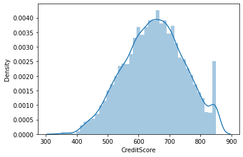

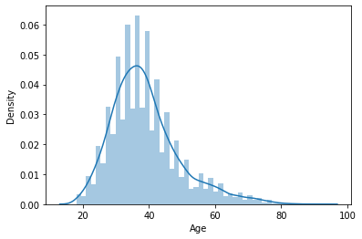

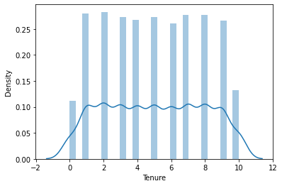

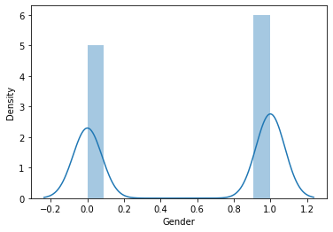

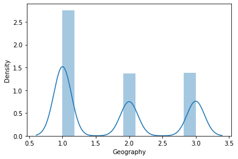

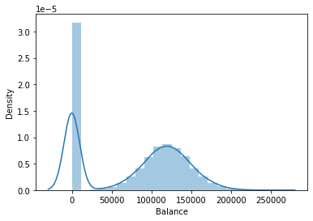

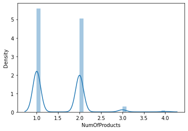

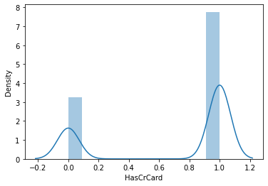

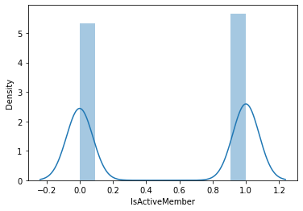

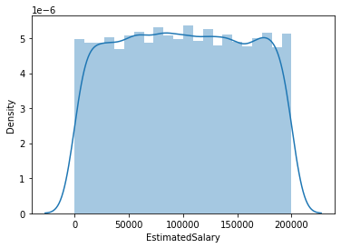

```python
# get the distplot for all the attributes
for i in ['CreditScore', 'Age', 'Tenure', 'Gender', "Geography",
       'Balance', 'NumOfProducts', 'HasCrCard', 'IsActiveMember',
       'EstimatedSalary']:
       sns.distplot(bank_df[i])
       plt.show()
```

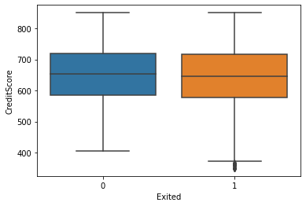

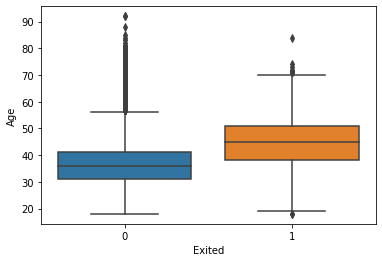

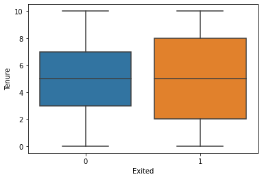

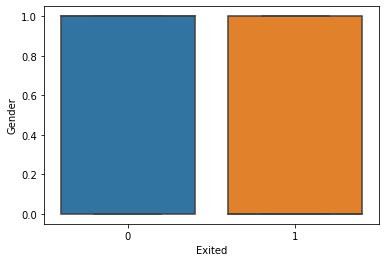

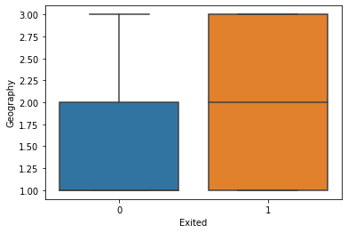

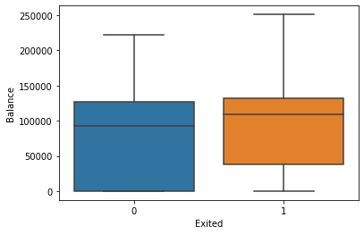

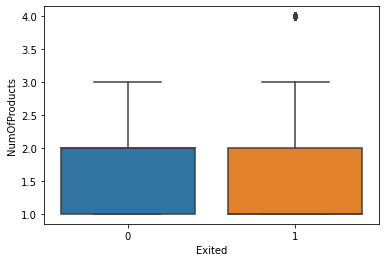

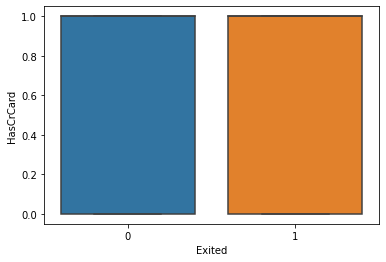

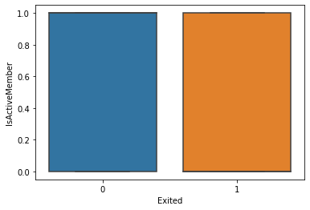

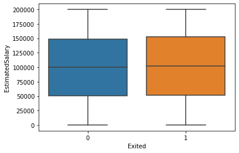

```python
# Bi Variate Plots
for i,col in enumerate(['CreditScore', 'Age', 'Tenure', 'Gender', "Geography",
       'Balance', 'NumOfProducts', 'HasCrCard', 'IsActiveMember',
       'EstimatedSalary']):
    sns.boxplot(x='Exited',y=col,data=bank_df)
    plt.show()
```

Bivariate Analysis

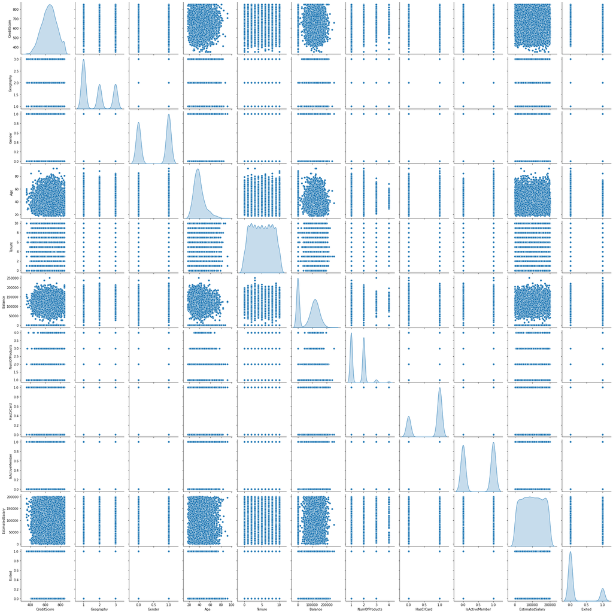

```python
# Getting the pairplot amongst the variables where diagonal graphs shows that the most of the attributes are having three to four spikes. which is ideal to have  to 4 groups
sns.pairplot(bank_df,diag_kind='kde')
```

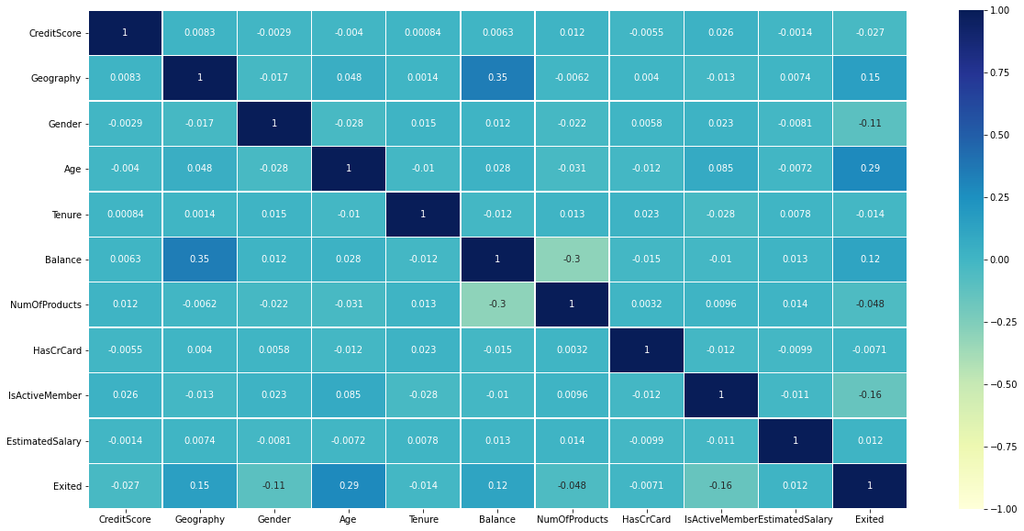

```python
# get the heat map to find the correlation amongst the attributes
plt.figure(figsize=(20,10))
sns.heatmap(bank_df.corr(),annot=True,linewidths=.5,center=0,cbar=True,cmap="YlGnBu",vmin=-1,vmax=+1)
plt.show()
```

With respect to data distribution is concerened data is distributed with 80:20 ratio for the Not Exited and Exited

```python
bank_df.shape
```

```
(10000, 11)
```

```python
# Check distributions for Class 0 vs 1
NotLeft= bank_df[bank_df.Exited==0]
LeftBank = bank_df[bank_df.Exited==1]
```

```python
LeftBank.describe().T
```

|  | count | mean | std | min | 25% | 50% | 75% | max |
| --- | --- | --- | --- | --- | --- | --- | --- | --- |
| CreditScore | 2037.0 | 645.351497 | 100.321503 | 350.00 | 578.00 | 646.00 | 716.00 | 850.00 |
| Geography | 2037.0 | 2.001964 | 0.893106 | 1.00 | 1.00 | 2.00 | 3.00 | 3.00 |
| Gender | 2037.0 | 0.440844 | 0.496610 | 0.00 | 0.00 | 0.00 | 1.00 | 1.00 |
| Age | 2037.0 | 44.837997 | 9.761562 | 18.00 | 38.00 | 45.00 | 51.00 | 84.00 |
| Tenure | 2037.0 | 4.932744 | 2.936106 | 0.00 | 2.00 | 5.00 | 8.00 | 10.00 |
| Balance | 2037.0 | 91108.539337 | 58360.794816 | 0.00 | 38340.02 | 109349.29 | 131433.33 | 250898.09 |
| NumOfProducts | 2037.0 | 1.475209 | 0.801521 | 1.00 | 1.00 | 1.00 | 2.00 | 4.00 |
| HasCrCard | 2037.0 | 0.699067 | 0.458776 | 0.00 | 0.00 | 1.00 | 1.00 | 1.00 |
| IsActiveMember | 2037.0 | 0.360825 | 0.480358 | 0.00 | 0.00 | 0.00 | 1.00 | 1.00 |
| EstimatedSalary | 2037.0 | 101465.677531 | 57912.418071 | 11.58 | 51907.72 | 102460.84 | 152422.91 | 199808.10 |
| Exited | 2037.0 | 1.000000 | 0.000000 | 1.00 | 1.00 | 1.00 | 1.00 | 1.00 |

```python
NotLeft.describe().T
```

|  | count | mean | std | min | 25% | 50% | 75% | max |
| --- | --- | --- | --- | --- | --- | --- | --- | --- |
| CreditScore | 7963.0 | 651.853196 | 95.653837 | 405.00 | 585.00 | 653.00 | 718.000 | 850.00 |
| Geography | 7963.0 | 1.684918 | 0.801002 | 1.00 | 1.00 | 1.00 | 2.000 | 3.00 |
| Gender | 7963.0 | 0.572523 | 0.494744 | 0.00 | 0.00 | 1.00 | 1.000 | 1.00 |
| Age | 7963.0 | 37.408389 | 10.125363 | 18.00 | 31.00 | 36.00 | 41.000 | 92.00 |
| Tenure | 7963.0 | 5.033279 | 2.880658 | 0.00 | 3.00 | 5.00 | 7.000 | 10.00 |
| Balance | 7963.0 | 72745.296779 | 62848.040701 | 0.00 | 0.00 | 92072.68 | 126410.280 | 221532.80 |
| NumOfProducts | 7963.0 | 1.544267 | 0.509536 | 1.00 | 1.00 | 2.00 | 2.000 | 3.00 |
| HasCrCard | 7963.0 | 0.707146 | 0.455101 | 0.00 | 0.00 | 1.00 | 1.000 | 1.00 |
| IsActiveMember | 7963.0 | 0.554565 | 0.497045 | 0.00 | 0.00 | 1.00 | 1.000 | 1.00 |
| EstimatedSalary | 7963.0 | 99738.391772 | 57405.586966 | 90.07 | 50783.49 | 99645.04 | 148609.955 | 199992.48 |
| Exited | 7963.0 | 0.000000 | 0.000000 | 0.00 | 0.00 | 0.00 | 0.000 | 0.00 |

```python
# Import `train_test_split` from `sklearn.model_selection`
from sklearn.model_selection import train_test_split

# Specify the data for the independant Variables
X=bank_df.iloc[:, :-1]

# Specify the target labels and flatten array
y= bank_df.iloc[:, -1]


# Split the data up in train, validation and test sets
X_Train, X_test, Y_Train, y_test = train_test_split(X,y, random_state = 1,test_size=0.2,train_size=0.8)
X_train, x_cv, y_train, y_cv = train_test_split(X_Train,Y_Train,test_size = 0.25,train_size =0.75,random_state=1)

#print the shape of the train, validation and test for independant and taarget variables
y_train =  np.array(y_train)
y_cv = np.array(y_cv)
y_test =  np.array(y_test)
print(X_train.shape)
print(x_cv.shape)
print(X_test.shape)
print(y_train.shape)
print(y_cv.shape)
print(y_test.shape)
```

```
(6000, 10)
(2000, 10)
(2000, 10)
(6000,)
(2000,)
(2000,)
```

```python
# Print the target variables values counts in percent
y.value_counts()/y.shape[0]*100
```

```
0    79.63
1    20.37
Name: Exited, dtype: float64
```

```python
y.value_counts()
```

```
0    7963
1    2037
Name: Exited, dtype: int64
```

**Creating a model**

Keras model object can be created with Sequential class It is completed by adding additional layers and compilation

```python
L=pd.DataFrame(y_train)
L[0].value_counts()
```

```
0    4793
1    1207
Name: 0, dtype: int64
```

```python
# preprocessing module includes scaling, centering and normalization.
X_train = preprocessing.normalize(X_train)
x_cv = preprocessing.normalize(x_cv)
X_test = preprocessing.normalize(X_test)
```

```python
#Standardize features by removing the mean and scaling to unit variance
#The standard score of a sample x is calculated as: z = (x - u) / s

from sklearn.preprocessing import StandardScaler

# Define the scaler
scaler = StandardScaler().fit(X_train)

# Scale the train set
X_train = scaler.transform(X_train)

# Scale the test set
X_test = scaler.transform(X_test)
```

**Deep Learning Model using tensorflow with Keras API package**

```python
#model = Sequential()
model = tf.keras.Sequential()
```

**Adding layers [layers and activations]**

Keras layers can be added to the model

Adding layers are like stacking lego blocks one by one

It should be noted that as this is a classification problem, sigmoid layer (softmax for multi-class problems) should be added

RandomUniform initializer is used as kernel initializer and bias initializer as zeros Input layer with 10 neuron for 10 attributes and two hiiden llayer with 100 and 50 neurons respectively and one neuron in the output layer as it has to predict 1 or o only

```python
initializer = tf.keras.initializers.RandomUniform(minval=0., maxval=1.)
model.add(Dense(100, input_shape = (10,), activation = 'relu', kernel_initializer = initializer, bias_initializer= 'zeros'))
model.add(Dense(50, activation = 'tanh'))
model.add(Dense(1, activation = 'sigmoid'))
# method.add - add dense layer - fully connected Network
```

**Model compile [optimizers and loss functions]**

Keras model should be "compiled" prior to training

Types of loss (function) and optimizer should be designated

```python
sgd = optimizers.Adam(lr = 0.001)
#Optimization Function adams is used
```

```python
model.compile(optimizer = sgd, loss = 'binary_crossentropy', metrics=['accuracy'])
# Loss for compare and gives us the error
```

**Summary of the Model**

```python
model.summary()
# All parameters and network created to train
```

```
Model: "sequential"
_________________________________________________________________
Layer (type)                 Output Shape              Param #
=================================================================
dense (Dense)                (None, 100)               1100
_________________________________________________________________
dense_1 (Dense)              (None, 50)                5050
_________________________________________________________________
dense_2 (Dense)              (None, 1)                 51
=================================================================
Total params: 6,201
Trainable params: 6,201
Non-trainable params: 0
_________________________________________________________________
```

**Training [Forward pass and Backpropagation]**

```python
# For 100 epoch training the model with batch size of data as 500
history = model.fit(X_train, y_train, batch_size = 250, epochs = 100, verbose = 1,validation_split=0.2)
```

```python
# Record all the history of epoch in a dataframe for plotting the graph
hist  = pd.DataFrame(history.history)
hist['epoch'] = history.epoch
```

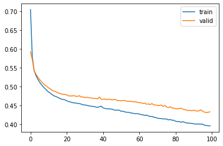

```python
#Plot the graph for loss and accuracy train and validation steps
plt.plot(hist['loss'])
plt.plot(hist['val_loss'])
plt.legend(("train" , "valid") , loc =0)
```

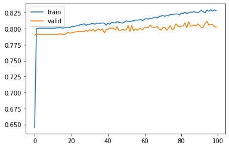

```python
plt.plot(hist['accuracy'])
plt.plot(hist['val_accuracy'])
plt.legend(("train" , "valid") , loc =0)
```

```python
# How loss moves around with each epoch
data_vis = [{'epoch': idx,
         'loss': history.history['loss'][idx],
         'val_loss': history.history['val_loss'][idx],
         'accuracy': history.history['accuracy'][idx],
         'val_accuracy': history.history['val_accuracy'][idx]
         } for idx in range(20)]
hip.Experiment.from_iterable(data_vis).display()
```

Loading HiPlot...

```
<hiplot.ipython.IPythonExperimentDisplayed at 0x7f1a8238e438>
```

**Evaluation**

Keras model can be evaluated with evaluate() function using the validation data set

Evaluation results are contained in a list

```python
results = model.evaluate(x_cv, y_cv)
```

```python
print(model.metrics_names)
print(results)
```

```
['loss', 'accuracy']
[0.5216647386550903, 0.7925000190734863]
```

```python
#Predict the result with the test data set without the threshold
Y_pred_cls = model.predict_classes(X_test, batch_size=200, verbose=0)
print('Accuracy Model1 (Dropout): '+ str(model.evaluate(X_test,y_test)[1]))
print('Recall_score: ' + str(recall_score(y_test,Y_pred_cls)))
print('Precision_score: ' + str(precision_score(y_test, Y_pred_cls)))
print('F-score: ' + str(f1_score(y_test,Y_pred_cls)))
confusion_matrix(y_test, Y_pred_cls)
#recall and precision high, Our model doing well
```

```
Accuracy Model1 (Dropout): 0.8134999871253967
Recall_score: 0.2385542168674699
Precision_score: 0.6346153846153846
F-score: 0.3467600700525394
```

```
array([[1528,   57],
       [ 316,   99]])
```

**Predict the result with the test data set with the threshold as 0.4**

```python
pred_y = model.predict(X_test)
y_pred = (pred_y > 0.4)
print('Accuracy Model1 (Dropout): '+ str(accuracy_score(y_test,y_pred)))
#str(model.evaluate(X_test,y_test)[1]))
print('Recall_score: ' + str(recall_score(y_test,y_pred)))
print('Precision_score: ' + str(precision_score(y_test, y_pred)))
print('F-score: ' + str(f1_score(y_test,y_pred)))
confusion_matrix(y_test, y_pred)
```

```
Accuracy Model1 (Dropout): 0.8245
Recall_score: 0.40240963855421685
Precision_score: 0.6185185185185185
F-score: 0.4875912408759124
```

```
array([[1482,  103],
       [ 248,  167]])
```

**Predict the result with the test data set with the threshold**

```python
pred_y = model.predict(X_test)
y_pred = (pred_y > 0.5)
print('Accuracy Model1 (Dropout): '+ str(accuracy_score(y_test,y_pred)))
#str(model.evaluate(X_test,y_test)[1]))
print('Recall_score: ' + str(recall_score(y_test,y_pred)))
print('Precision_score: ' + str(precision_score(y_test, y_pred)))
print('F-score: ' + str(f1_score(y_test,y_pred)))
confusion_matrix(y_test, y_pred)
```

```
Accuracy Model1 (Dropout): 0.828
Recall_score: 0.3132530120481928
Precision_score: 0.6878306878306878
F-score: 0.43046357615894043
```

```
array([[1526,   59],
       [ 285,  130]])
```

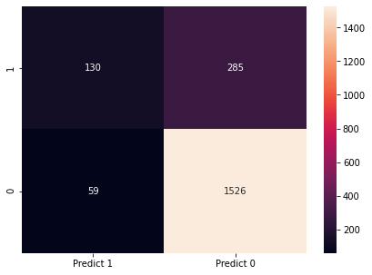

```python
# This block of code here prints out the confusion matrix to identify FP,FN,TP and TN
# We also print out important metrics
cm=metrics.confusion_matrix(y_test, y_pred, labels=[1, 0])

df_cm = pd.DataFrame(cm, index = [i for i in ["1","0"]],
                  columns = [i for i in ["Predict 1","Predict 0"]])
plt.figure(figsize = (7,5))
sns.heatmap(df_cm, annot=True,fmt="d")
```

```python
initializer = tf.keras.initializers.RandomUniform(minval=0., maxval=1.)
model.add(Dense(100, input_shape = (10,), activation = 'relu', kernel_initializer = initializer, bias_initializer= 'zeros'))
model.add(Dense(50, activation = 'tanh'))
model.add(Dense(1, activation = 'sigmoid'))
# method.add - add dense layer - fully connected Network
```

```python
sgd = optimizers.Adagrad(lr = 0.001)
#Optimization Function ADAGRAD is used
model.compile(optimizer = sgd, loss = 'binary_crossentropy', metrics=['accuracy'])
# Loss for compare and gives us the error
```

```python
# For 100 epoch training the model with batch size of data as 500
history = model.fit(X_train, y_train, batch_size = 250, epochs = 100, verbose = 1,validation_split=0.2)
```

```python
results = model.evaluate(x_cv, y_cv)
```

```python
print(model.metrics_names)
print(results)
```

```
['loss', 'accuracy']
[0.5382241010665894, 0.7925000190734863]
```

```python
#Predict the result with the test data set without the threshold
Y_pred_cls = model.predict_classes(X_test, batch_size=200, verbose=0)
print('Accuracy Model1 (Dropout): '+ str(model.evaluate(X_test,y_test)[1]))
print('Recall_score: ' + str(recall_score(y_test,Y_pred_cls)))
print('Precision_score: ' + str(precision_score(y_test, Y_pred_cls)))
print('F-score: ' + str(f1_score(y_test,Y_pred_cls)))
confusion_matrix(y_test, Y_pred_cls)
#recall and precision high, Our model doing well
```

```
Accuracy Model1 (Dropout): 0.7925000190734863
Recall_score: 0.0
Precision_score: 0.0
F-score: 0.0
```

```
array([[1585,    0],
       [ 415,    0]])
```

```python
pred_y = model.predict(X_test)
y_pred = (pred_y > 0.5)
print('Accuracy Model1 (Dropout): '+ str(accuracy_score(y_test,y_pred)))
#str(model.evaluate(X_test,y_test)[1]))
print('Recall_score: ' + str(recall_score(y_test,y_pred)))
print('Precision_score: ' + str(precision_score(y_test, y_pred)))
print('F-score: ' + str(f1_score(y_test,y_pred)))
confusion_matrix(y_test, y_pred)
```

```
Accuracy Model1 (Dropout): 0.7925
Recall_score: 0.0
Precision_score: 0.0
F-score: 0.0
```

```
array([[1585,    0],
       [ 415,    0]])
```

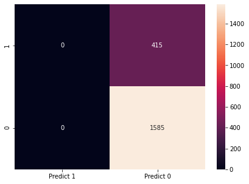

```python
# This block of code here prints out the confusion matrix to identify FP,FN,TP and TN
# We also print out important metrics
cm=metrics.confusion_matrix(y_test, y_pred, labels=[1, 0])

df_cm = pd.DataFrame(cm, index = [i for i in ["1","0"]],
                  columns = [i for i in ["Predict 1","Predict 0"]])
plt.figure(figsize = (7,5))
sns.heatmap(df_cm, annot=True,fmt="d")
```

[output not shown]

```
keras is no longer supported, please use tf.keras instead.
You have provided over 5k background samples! For better performance consider using smaller random sample.
```

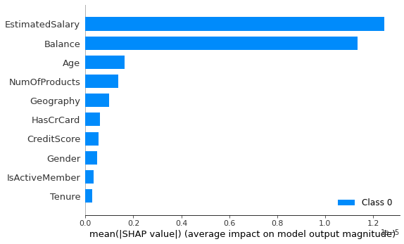

```python
## Explain Model Better using SHAP ( Similar to LIME used before ) - Feature Importance
import shap
shap.initjs()
explainer = shap.DeepExplainer(model, X_train[:10000])
shap_values = explainer.shap_values(X_test[:10000])
shap.summary_plot(shap_values, pd.DataFrame(X_test,columns = X.columns), plot_type='bar')
```

```python
# Keras Functional API - better use cases when we work on Computer Vision / Embedding problems.
from keras.layers import Input
from keras.layers import concatenate
from keras import Model
```

```python
def build_model(hp):
    initializer = tf.keras.initializers.RandomUniform(minval=0., maxval=1.)
    model_1 = tf.keras.Sequential() #Start model
    model_1.add(Dense(units=hp.Int('units_in',min_value=16,max_value=256,step=32),
                    input_shape = (10,),
                    activation = hp.Choice('act_in', ['relu', 'tanh']), kernel_initializer = initializer, bias_initializer= 'zeros')) # Hidden Layer connected to Input Layer
    for i in range(hp.Int('num_layers', 0, 2)):
      model_1.add(Dense(units=hp.Int('units_' + str(i),
                                            min_value=32,
                                            max_value=512,
                                            step=32),
                               activation=hp.Choice('act_' + str(i), ['relu', 'tanh'])))  # Hidden Layer
      model_1.add(Dropout(hp.Float('dropout', 0, 0.5, step=0.1, default=0.3))) # Drop out layer for regularization

    model_1.add(Dense(1, activation='sigmoid')) # Output layer

    model_1.compile(
         optimizer=optimizers.Adam(
             hp.Choice('learning_rate', [1e-2, 1e-3, 1e-4])),
             loss='binary_crossentropy',
             metrics=['accuracy'])
    return model_1
```

```python
tuner = RandomSearch(
    build_model,
    objective='val_accuracy',
    max_trials=3,
    executions_per_trial=2,
    directory='DNN',
    project_name='BankCustomerRetain_Proj6')
```

[output not shown]

```python
tuner.search_space_summary()
```

```
Search space summary
Default search space size: 7
units_in (Int)
{'default': None, 'conditions': [], 'min_value': 16, 'max_value': 256, 'step': 32, 'sampling': None}
act_in (Choice)
{'default': 'relu', 'conditions': [], 'values': ['relu', 'tanh'], 'ordered': False}
num_layers (Int)
{'default': None, 'conditions': [], 'min_value': 0, 'max_value': 2, 'step': 1, 'sampling': None}
learning_rate (Choice)
{'default': 0.01, 'conditions': [], 'values': [0.01, 0.001, 0.0001], 'ordered': True}
units_0 (Int)
{'default': None, 'conditions': [], 'min_value': 32, 'max_value': 512, 'step': 32, 'sampling': None}
act_0 (Choice)
{'default': 'relu', 'conditions': [], 'values': ['relu', 'tanh'], 'ordered': False}
dropout (Float)
{'default': 0.3, 'conditions': [], 'min_value': 0.0, 'max_value': 0.5, 'step': 0.1, 'sampling': None}
```

```python
tuner.search(X_train, y_train, epochs = 10, batch_size= 500, validation_split = 0.2)
```

```
INFO:tensorflow:Oracle triggered exit
```

```python
#Summary of best results
print(tuner.results_summary())
```

```
Results summary
Results in DNN/BankCustomerRetain_Proj6
Showing 10 best trials
Objective(name='val_accuracy', direction='max')
Trial summary
Hyperparameters:
units_in: 144
act_in: relu
num_layers: 1
learning_rate: 0.001
units_0: 512
act_0: relu
dropout: 0.30000000000000004
Score: 0.8016666769981384
Trial summary
Hyperparameters:
units_in: 144
act_in: relu
num_layers: 0
learning_rate: 0.0001
Score: 0.7912500202655792
Trial summary
Hyperparameters:
units_in: 176
act_in: tanh
num_layers: 1
learning_rate: 0.0001
units_0: 32
act_0: relu
dropout: 0.3
Score: 0.7908333539962769
None
```

```python
best_model = tuner.get_best_models(num_models=1)[0]
results = best_model.evaluate(X_test, y_test)
```

**Conclusion:** Businesses like banks that provide service have to worry about the problem i.e. Obective is to predict the customers one who may leave the bank based on the available dataset and provide proactive counselling and improve the bank services to retain them.

It is important to understand which aspects of the service influence a customer's decision in this regard. Management can concentrate efforts on the improvement of service, keeping in mind these priorities.

**Data Description:**

The case study is from an open-source dataset from Kaggle. The dataset contains 10,000 sample points with 14 distinct features such as CustomerId, CreditScore, Geography, Gender, Age, Tenure, Balance, etc.

In which Row number and CustomerId are the Unique identification key for different customers and which is not contributing to predict the target variable so these columns are dropped.

**Insight from the Bivariate Analysis:**

With respect to data distribution is concerened data is distributed with 80:20 ratio for the Not Exited and Exited

**Model Building**

Adding layers are like stacking lego blocks one by one

It should be noted that as this is a classification problem, sigmoid layer (softmax for multi-class problems) should be added

**RandomUniform initializer is used as kernel initializer and bias initializer as zeros.**

Input layer with 10 neuron for 10 attributes and two hidden layer with 100 and 50 neurons respectively and one neuron in the output layer as it has to predict 1 or o only